# CreValu - Credit Status Prediction

```python
import pandas as pd
import matplotlib.pyplot as plt
import seaborn as sns
from sklearn.model_selection import train_test_split
from sklearn.preprocessing import StandardScaler, OneHotEncoder
from sklearn.linear_model import LogisticRegression
from sklearn.metrics import accuracy_score, classification_report
from imblearn.over_sampling import SMOTE
from sklearn.ensemble import RandomForestClassifier
import warnings

warnings.filterwarnings("ignore")
```

```python
df = pd.read_csv("./loan_data_updated.csv")
df.head()
```

|  | loan_id | applicant_gender | applicant_married | applicant_dependents | applicant_education | applicant_employment | applicant_income | applicant_employment_history | applicant_credit_score | applicant_credit_default | ... | co_applicant | co_applicant_income | co_applicant_employment | co_applicant_employment_history | co_applicant_credit_score | co_applicant_credit_default | loan_amount | loan_amount_term | property_area | loan_status |
| --- | --- | --- | --- | --- | --- | --- | --- | --- | --- | --- | --- | --- | --- | --- | --- | --- | --- | --- | --- | --- | --- |
| 0 | LP001003 | Male | True | 1 | Graduate | Salaried | 4583 | 34 | 580 | True | ... | False | 1508.0 | Not Applicable | 0 | 650 | False | 128.0 | 360.0 | Rural | False |
| 1 | LP001005 | Male | True | 0 | Graduate | Self-Employed | 3000 | 29 | 823 | True | ... | True | 0.0 | Salaried | 8 | 759 | False | 66.0 | 360.0 | Urban | True |
| 2 | LP001006 | Male | True | 0 | Not Graduate | Salaried | 2583 | 8 | 710 | False | ... | False | 2358.0 | Not Applicable | 0 | 650 | False | 120.0 | 360.0 | Urban | True |
| 3 | LP001008 | Male | False | 0 | Graduate | Salaried | 6000 | 29 | 838 | False | ... | True | 0.0 | Self-Employed | 4 | 861 | False | 141.0 | 360.0 | Urban | True |
| 4 | LP001013 | Male | True | 0 | Not Graduate | Salaried | 2333 | 47 | 727 | False | ... | True | 1516.0 | Salaried | 7 | 607 | False | 95.0 | 360.0 | Urban | True |

5 rows × 21 columns

- loan_id: Identifier for the loan (unique for each row).
- applicant_gender, applicant_married, applicant_dependents, applicant_education, applicant_employment: Demographic and employment information about the applicant.
- applicant_income, applicant_employment_history, applicant_credit_score, applicant_credit_default, applicant_credit_history: Financial and credit history details of the applicant.
- co_applicant, co_applicant_income, co_applicant_employment, co_applicant_employment_history, co_applicant_credit_score, co_applicant_credit_default: Similar details for a co-applicant, if any.
- loan_amount, loan_amount_term: Details about the requested loan.
- property_area: Location type of the property.
- loan_status: Target variable indicating if the loan was approved or not.

```python
df.drop(["loan_id"], axis = 1, inplace= True)
```

### EDA Exploration

```python
# General Statistics
df.describe()
```

|  | applicant_income | applicant_employment_history | applicant_credit_score | applicant_credit_history | co_applicant_income | co_applicant_employment_history | co_applicant_credit_score | loan_amount | loan_amount_term |
| --- | --- | --- | --- | --- | --- | --- | --- | --- | --- |
| count | 381.000000 | 381.000000 | 381.000000 | 381.000000 | 381.000000 | 381.000000 | 381.000000 | 381.000000 | 370.000000 |
| mean | 3579.845144 | 34.695538 | 700.601050 | 47.181102 | 1277.275381 | 11.603675 | 670.026247 | 104.986877 | 340.864865 |
| std | 1419.813818 | 17.487340 | 148.372286 | 12.863504 | 2340.818114 | 15.444907 | 91.686849 | 28.358464 | 68.549257 |
| min | 150.000000 | 0.000000 | 300.000000 | 4.000000 | 0.000000 | 0.000000 | 403.000000 | 9.000000 | 12.000000 |
| 25% | 2600.000000 | 22.000000 | 644.000000 | 41.000000 | 0.000000 | 0.000000 | 650.000000 | 90.000000 | 360.000000 |
| 50% | 3333.000000 | 37.000000 | 726.000000 | 51.000000 | 983.000000 | 0.000000 | 650.000000 | 110.000000 | 360.000000 |
| 75% | 4288.000000 | 50.000000 | 817.000000 | 57.000000 | 2016.000000 | 23.000000 | 687.000000 | 127.000000 | 360.000000 |
| max | 9703.000000 | 60.000000 | 899.000000 | 60.000000 | 33837.000000 | 48.000000 | 899.000000 | 150.000000 | 480.000000 |

```python
df.info()
```

```
<class 'pandas.core.frame.DataFrame'>
RangeIndex: 381 entries, 0 to 380
Data columns (total 20 columns):
 #   Column                           Non-Null Count  Dtype
---  ------                           --------------  -----
 0   applicant_gender                 376 non-null    object
 1   applicant_married                381 non-null    bool
 2   applicant_dependents             373 non-null    object
 3   applicant_education              381 non-null    object
 4   applicant_employment             381 non-null    object
 5   applicant_income                 381 non-null    int64
 6   applicant_employment_history     381 non-null    int64
 7   applicant_credit_score           381 non-null    int64
 8   applicant_credit_default         381 non-null    bool
 9   applicant_credit_history         381 non-null    int64
 10  co_applicant                     381 non-null    bool
 11  co_applicant_income              381 non-null    float64
 12  co_applicant_employment          381 non-null    object
 13  co_applicant_employment_history  381 non-null    int64
 14  co_applicant_credit_score        381 non-null    int64
 15  co_applicant_credit_default      381 non-null    bool
 16  loan_amount                      381 non-null    float64
 17  loan_amount_term                 370 non-null    float64
 18  property_area                    381 non-null    object
 19  loan_status                      381 non-null    bool
dtypes: bool(5), float64(3), int64(6), object(6)
memory usage: 46.6+ KB
```

```python
categorical_features = [
    'applicant_gender', 'applicant_married', 'applicant_dependents',
    'applicant_education', 'applicant_employment', 'applicant_credit_default',
    'co_applicant', 'co_applicant_employment', 'co_applicant_credit_default',
    'property_area', 'loan_status'
]

numerical_features = [
    'applicant_income', 'applicant_employment_history', 'applicant_credit_score',
    'applicant_credit_history', 'co_applicant_income', 'co_applicant_employment_history',
    'co_applicant_credit_score', 'loan_amount', 'loan_amount_term'
]
```

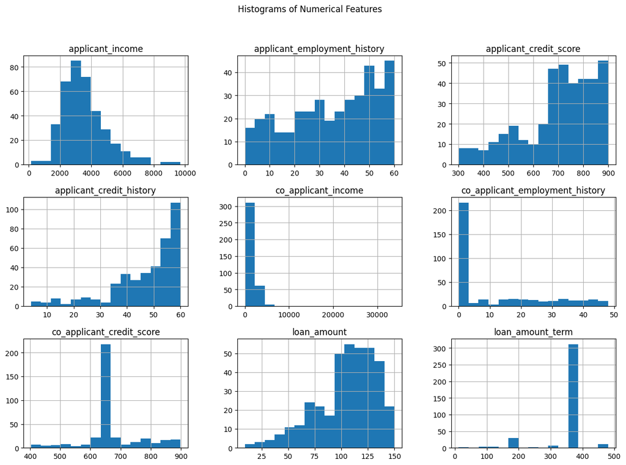

```python
# Histograms for numerical features
df[numerical_features].hist(bins=15, figsize=(15, 10))
plt.suptitle('Histograms of Numerical Features')
plt.show()
```

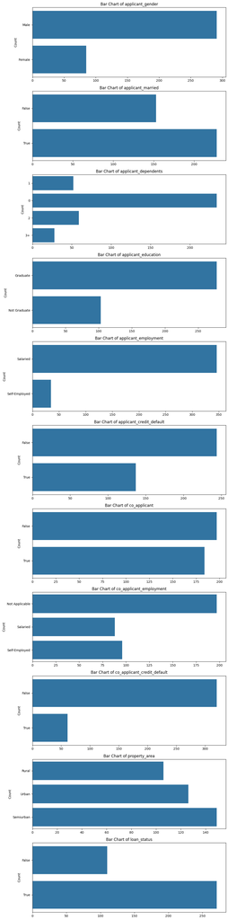

```python
# Bar charts for categorical features
fig, axes = plt.subplots(nrows=len(categorical_features), ncols=1, figsize=(10, 40))
for i, col in enumerate(categorical_features):
    sns.countplot(y=col, data=df, ax=axes[i])
    axes[i].set_title(f'Bar Chart of {col}')
    axes[i].set_xlabel('')
    axes[i].set_ylabel('Count')
plt.tight_layout()
plt.show()
```

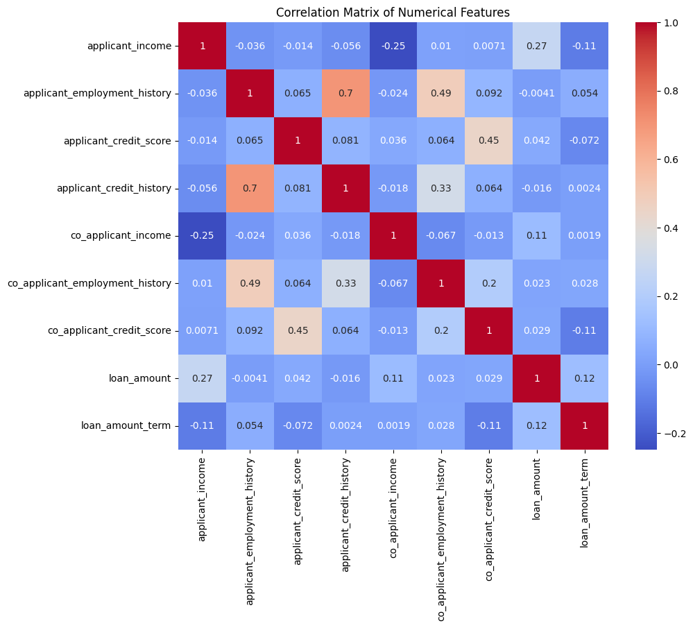

```python
# Correlation matrix
corr_matrix = df[numerical_features].corr()
plt.figure(figsize=(10, 8))
sns.heatmap(corr_matrix, annot=True, cmap='coolwarm')
plt.title('Correlation Matrix of Numerical Features')
plt.show()
```

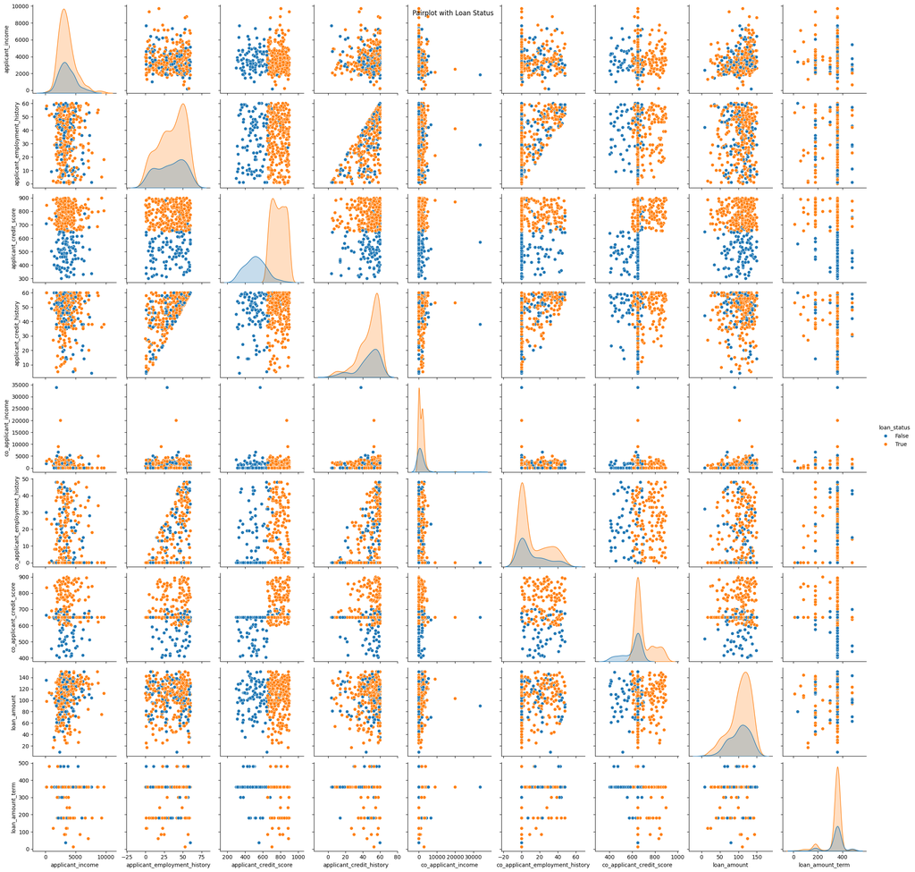

```python
# Pairplot for selected features against the loan status
sns.pairplot(df, vars=numerical_features, hue='loan_status')
plt.suptitle('Pairplot with Loan Status')
plt.show()
```

- Clusters of points separated by color, indicating a potential interaction between those variables and the loan status.
- Patterns such as upward or downward trends in the scatter plots that might indicate positive or negative correlations.
- Variations in the histograms or density plots, which could suggest that certain values of a variable are more likely to correspond to one loan status category or another.

```python
df['loan_status'].value_counts()
```

```
loan_status
True     271
False    110
Name: count, dtype: int64
```

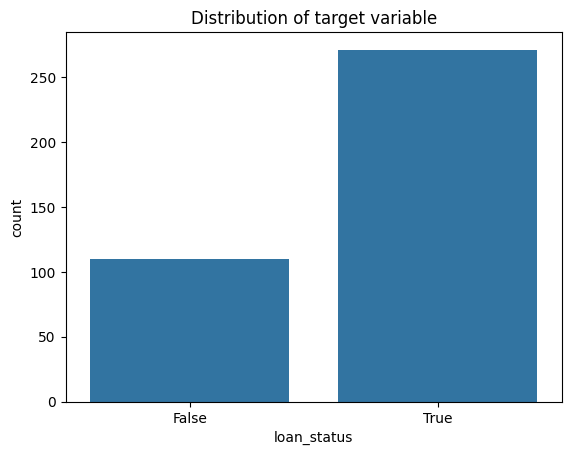

```python
sns.countplot(data = df, x='loan_status')
plt.title("Distribution of target variable")
plt.show()
```

### Data Preprocessing

```python
# Checking for missing values
print("Missing values per column:")
df.isnull().sum()
```

```
Missing values per column:
```

```
applicant_gender                    5
applicant_married                   0
applicant_dependents                8
applicant_education                 0
applicant_employment                0
applicant_income                    0
applicant_employment_history        0
applicant_credit_score              0
applicant_credit_default            0
applicant_credit_history            0
co_applicant                        0
co_applicant_income                 0
co_applicant_employment             0
co_applicant_employment_history     0
co_applicant_credit_score           0
co_applicant_credit_default         0
loan_amount                         0
loan_amount_term                   11
property_area                       0
loan_status                         0
dtype: int64
```

```python
df = df.drop_duplicates().reset_index(drop=True)
```

```python
df.dropna(inplace=True)
```

```python
df.columns
```

```
Index(['applicant_gender', 'applicant_married', 'applicant_dependents',
       'applicant_education', 'applicant_employment', 'applicant_income',
       'applicant_employment_history', 'applicant_credit_score',
       'applicant_credit_default', 'applicant_credit_history', 'co_applicant',
       'co_applicant_income', 'co_applicant_employment',
       'co_applicant_employment_history', 'co_applicant_credit_score',
       'co_applicant_credit_default', 'loan_amount', 'loan_amount_term',
       'property_area', 'loan_status'],
      dtype='object')
```

```python
df.head(n=10)
```

|  | applicant_gender | applicant_married | applicant_dependents | applicant_education | applicant_employment | applicant_income | applicant_employment_history | applicant_credit_score | applicant_credit_default | applicant_credit_history | co_applicant | co_applicant_income | co_applicant_employment | co_applicant_employment_history | co_applicant_credit_score | co_applicant_credit_default | loan_amount | loan_amount_term | property_area | loan_status |
| --- | --- | --- | --- | --- | --- | --- | --- | --- | --- | --- | --- | --- | --- | --- | --- | --- | --- | --- | --- | --- |
| 0 | Male | True | 1 | Graduate | Salaried | 4583 | 34 | 580 | True | 60 | False | 1508.0 | Not Applicable | 0 | 650 | False | 128.0 | 360.0 | Rural | False |
| 1 | Male | True | 0 | Graduate | Self-Employed | 3000 | 29 | 823 | True | 35 | True | 0.0 | Salaried | 8 | 759 | False | 66.0 | 360.0 | Urban | True |
| 2 | Male | True | 0 | Not Graduate | Salaried | 2583 | 8 | 710 | False | 14 | False | 2358.0 | Not Applicable | 0 | 650 | False | 120.0 | 360.0 | Urban | True |
| 3 | Male | False | 0 | Graduate | Salaried | 6000 | 29 | 838 | False | 49 | True | 0.0 | Self-Employed | 4 | 861 | False | 141.0 | 360.0 | Urban | True |
| 4 | Male | True | 0 | Not Graduate | Salaried | 2333 | 47 | 727 | False | 54 | True | 1516.0 | Salaried | 7 | 607 | False | 95.0 | 360.0 | Urban | True |
| 5 | Male | True | 2 | Graduate | Salaried | 3200 | 23 | 842 | True | 34 | False | 700.0 | Not Applicable | 0 | 650 | False | 70.0 | 360.0 | Urban | True |
| 6 | Male | True | 2 | Graduate | Salaried | 2500 | 34 | 688 | False | 36 | False | 1840.0 | Not Applicable | 0 | 650 | False | 109.0 | 360.0 | Urban | True |
| 7 | Male | False | 0 | Graduate | Salaried | 1853 | 43 | 800 | False | 52 | True | 2840.0 | Self-Employed | 11 | 698 | True | 114.0 | 360.0 | Rural | False |
| 8 | Male | True | 2 | Graduate | Salaried | 1299 | 2 | 886 | False | 27 | False | 1086.0 | Not Applicable | 0 | 650 | False | 17.0 | 120.0 | Urban | True |
| 9 | Male | False | 0 | Graduate | Salaried | 4950 | 51 | 887 | False | 54 | True | 0.0 | Salaried | 25 | 888 | False | 125.0 | 360.0 | Urban | True |

```python
df.applicant_gender = df.applicant_gender.apply(lambda x: 1 if str(x).lower() == "male" else 0)
df.applicant_education = df.applicant_education.apply(lambda x: 1 if str(x).lower() == "graduate" else 0)
df.applicant_employment = df.applicant_employment.apply(lambda x: 1 if str(x).lower() == "Salaried" else 0)
df.co_applicant_employment = df.co_applicant_employment.apply(lambda x: 1 if str(x).lower() == "Salaried" else 0)
df.applicant_credit_default = df.applicant_credit_default.apply(lambda x: 1 if x == False else 0)
```

```python
cols_to_encode = ['applicant_dependents', "property_area"]
df = pd.get_dummies(df, columns=cols_to_encode, drop_first=True)
df.head()
```

|  | applicant_gender | applicant_married | applicant_education | applicant_employment | applicant_income | applicant_employment_history | applicant_credit_score | applicant_credit_default | applicant_credit_history | co_applicant | ... | co_applicant_credit_score | co_applicant_credit_default | loan_amount | loan_amount_term | loan_status | applicant_dependents_1 | applicant_dependents_2 | applicant_dependents_3+ | property_area_Semiurban | property_area_Urban |
| --- | --- | --- | --- | --- | --- | --- | --- | --- | --- | --- | --- | --- | --- | --- | --- | --- | --- | --- | --- | --- | --- |
| 0 | 1 | True | 1 | 0 | 4583 | 34 | 580 | 0 | 60 | False | ... | 650 | False | 128.0 | 360.0 | False | True | False | False | False | False |
| 1 | 1 | True | 1 | 0 | 3000 | 29 | 823 | 0 | 35 | True | ... | 759 | False | 66.0 | 360.0 | True | False | False | False | False | True |
| 2 | 1 | True | 0 | 0 | 2583 | 8 | 710 | 1 | 14 | False | ... | 650 | False | 120.0 | 360.0 | True | False | False | False | False | True |
| 3 | 1 | False | 1 | 0 | 6000 | 29 | 838 | 1 | 49 | True | ... | 861 | False | 141.0 | 360.0 | True | False | False | False | False | True |
| 4 | 1 | True | 0 | 0 | 2333 | 47 | 727 | 1 | 54 | True | ... | 607 | False | 95.0 | 360.0 | True | False | False | False | False | True |

5 rows × 23 columns

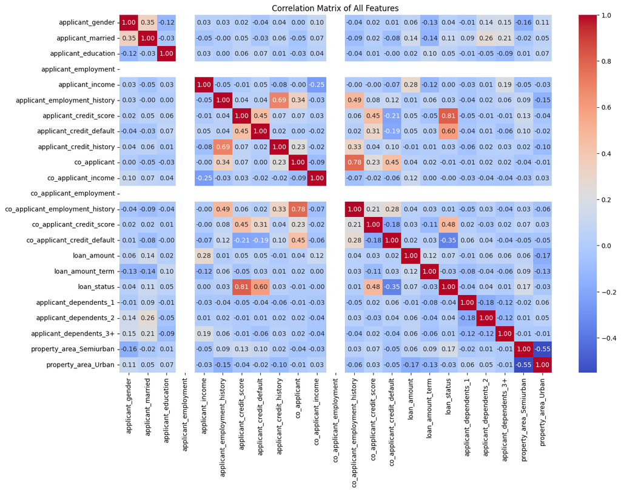

```python
# Compute the correlation matrix
correlation_matrix = df.corr()

# Use seaborn to create a heatmap to visualize the correlation matrix
plt.figure(figsize=(15, 10))
sns.heatmap(correlation_matrix, annot=True, fmt=".2f", cmap='coolwarm')
plt.title('Correlation Matrix of All Features')
plt.show()
```

- Diagonal: The diagonal from the top-left to the bottom-right shows a perfect correlation of 1, as this is each variable correlated with itself.
- Positive Correlations: Light to dark red squares indicate variables that have a positive correlation. For example, if applicant_income has a red square in the column under loan_amount, it would indicate that higher applicant income is generally associated with larger loan amounts.
- Negative Correlations: Light to dark blue squares represent negative correlations. For instance, if there is a dark blue square at the intersection of applicant_income and co_applicant_income, it could indicate that generally when one is high, the other is low.
- Close to Zero: White or lighter colored squares suggest no significant correlation. This means the variables don't have a strong linear relationship.

### Scenerio 1:

```python
#making a copy of the dataframe
df1 = df.copy()
```

```python
# function for loan approval
def custom_loan_approval_1(row):
    if (row['applicant_income'] >= 2000 and
        row['applicant_credit_score'] >= 650 and
        row['applicant_credit_history'] >= 30 and
        row['applicant_employment_history'] >= 18 and
        not row['applicant_credit_default']):
        return True
    else:
        return False

def process_loan_application(row):
    if custom_loan_approval_1(row):
        return "Approved"
    else:
        return "Rejected"

# Apply the function to each row in the DataFrame
df1['custom_loan_status'] = df1.apply(process_loan_application, axis=1)

# Display the result
df1[
    ['applicant_income', 'applicant_credit_score', 'applicant_credit_history',  'applicant_employment_history', 'applicant_credit_default', 'custom_loan_status']
].sample(n=20)
```

|  | applicant_income | applicant_credit_score | applicant_credit_history | applicant_employment_history | applicant_credit_default | custom_loan_status |
| --- | --- | --- | --- | --- | --- | --- |
| 279 | 1926 | 666 | 36 | 22 | 1 | Rejected |
| 162 | 2060 | 747 | 5 | 2 | 1 | Rejected |
| 51 | 1875 | 722 | 49 | 48 | 1 | Rejected |
| 3 | 6000 | 838 | 49 | 29 | 1 | Rejected |
| 21 | 3167 | 374 | 24 | 8 | 0 | Rejected |
| 2 | 2583 | 710 | 14 | 8 | 1 | Rejected |
| 374 | 3833 | 796 | 42 | 39 | 1 | Rejected |
| 41 | 2708 | 700 | 56 | 53 | 1 | Rejected |
| 365 | 3166 | 662 | 58 | 58 | 1 | Rejected |
| 262 | 2253 | 862 | 57 | 56 | 1 | Rejected |
| 364 | 1836 | 570 | 38 | 29 | 0 | Rejected |
| 69 | 1759 | 711 | 60 | 49 | 1 | Rejected |
| 182 | 3075 | 874 | 42 | 37 | 1 | Rejected |
| 194 | 3762 | 869 | 51 | 49 | 1 | Rejected |
| 58 | 3988 | 799 | 41 | 19 | 1 | Rejected |
| 18 | 4226 | 761 | 14 | 1 | 1 | Rejected |
| 255 | 2755 | 380 | 53 | 46 | 1 | Rejected |
| 248 | 3100 | 744 | 27 | 20 | 1 | Rejected |
| 312 | 3597 | 420 | 59 | 58 | 0 | Rejected |
| 345 | 3358 | 557 | 60 | 60 | 0 | Rejected |

```python
df1.custom_loan_status.value_counts()
```

```
custom_loan_status
Rejected    323
Approved     35
Name: count, dtype: int64
```

```python
# Fature and target Variables
X = df1.drop(['loan_status', 'custom_loan_status'], axis=1)
y = df1['custom_loan_status']

X_train, X_test, y_train, y_test = train_test_split(X, y, test_size=0.2, random_state=42)
```

```python
# Normalization
scaler = StandardScaler()
X_train_scaled = scaler.fit_transform(X_train)
X_test_scaled = scaler.transform(X_test)
```

```python
#Model Training
model = LogisticRegression()
model.fit(X_train_scaled, y_train)
```

```
LogisticRegression()
```

```python
#Prediction
y_pred = model.predict(X_test_scaled)
print("Accuracy:", accuracy_score(y_test, y_pred))
print("Classification Report:\n", classification_report(y_test, y_pred))
```

```
Accuracy: 0.9583333333333334
Classification Report:
               precision    recall  f1-score   support

    Approved       0.83      0.71      0.77         7
    Rejected       0.97      0.98      0.98        65

    accuracy                           0.96        72
   macro avg       0.90      0.85      0.87        72
weighted avg       0.96      0.96      0.96        72
```

```python
importances = pd.DataFrame(data={
    'Attribute': X_train.columns,
    'Importance': model.coef_[0]
})
importances = importances.sort_values(by='Importance', ascending=False)
print(importances)
```

```
                          Attribute  Importance
7          applicant_credit_default    2.885359
8          applicant_credit_history    0.483251
21              property_area_Urban    0.347677
12  co_applicant_employment_history    0.245248
9                      co_applicant    0.056973
1                 applicant_married    0.045777
11          co_applicant_employment    0.000000
3              applicant_employment    0.000000
10              co_applicant_income   -0.013071
14      co_applicant_credit_default   -0.021698
20          property_area_Semiurban   -0.083834
4                  applicant_income   -0.087372
16                 loan_amount_term   -0.097783
18           applicant_dependents_2   -0.136157
19          applicant_dependents_3+   -0.152444
15                      loan_amount   -0.162195
2               applicant_education   -0.205754
13        co_applicant_credit_score   -0.300519
0                  applicant_gender   -0.361839
17           applicant_dependents_1   -0.461033
5      applicant_employment_history   -1.322473
6            applicant_credit_score   -1.877355
```

```python
# Using a random forest for potentially better performance
rf_model = RandomForestClassifier(n_estimators=100, random_state=42)
rf_model.fit(X_train_scaled, y_train)
y_pred_rf = rf_model.predict(X_test_scaled)

print("RF Accuracy:", accuracy_score(y_test, y_pred_rf))
print("RF Classification Report:\n", classification_report(y_test, y_pred_rf))
```

```
RF Accuracy: 0.9444444444444444
RF Classification Report:
               precision    recall  f1-score   support

    Approved       1.00      0.43      0.60         7
    Rejected       0.94      1.00      0.97        65

    accuracy                           0.94        72
   macro avg       0.97      0.71      0.79        72
weighted avg       0.95      0.94      0.93        72
```

### Scenerio 2:

- Applicant credit score < 650.
- Applicant credit history < 10.
- Whether Co-applicant - Yes/No.
- If Yes, Co-applicant Credit Score >= 650.
- Co-applicant Credit Default = False
- Based on the condition, Approval/ Rejection.

```python
#making a copy of the dataframe
df2 = df.copy()
df2
```

|  | applicant_gender | applicant_married | applicant_education | applicant_employment | applicant_income | applicant_employment_history | applicant_credit_score | applicant_credit_default | applicant_credit_history | co_applicant | ... | co_applicant_credit_score | co_applicant_credit_default | loan_amount | loan_amount_term | loan_status | applicant_dependents_1 | applicant_dependents_2 | applicant_dependents_3+ | property_area_Semiurban | property_area_Urban |
| --- | --- | --- | --- | --- | --- | --- | --- | --- | --- | --- | --- | --- | --- | --- | --- | --- | --- | --- | --- | --- | --- |
| 0 | 1 | True | 1 | 0 | 4583 | 34 | 580 | 0 | 60 | False | ... | 650 | False | 128.0 | 360.0 | False | True | False | False | False | False |
| 1 | 1 | True | 1 | 0 | 3000 | 29 | 823 | 0 | 35 | True | ... | 759 | False | 66.0 | 360.0 | True | False | False | False | False | True |
| 2 | 1 | True | 0 | 0 | 2583 | 8 | 710 | 1 | 14 | False | ... | 650 | False | 120.0 | 360.0 | True | False | False | False | False | True |
| 3 | 1 | False | 1 | 0 | 6000 | 29 | 838 | 1 | 49 | True | ... | 861 | False | 141.0 | 360.0 | True | False | False | False | False | True |
| 4 | 1 | True | 0 | 0 | 2333 | 47 | 727 | 1 | 54 | True | ... | 607 | False | 95.0 | 360.0 | True | False | False | False | False | True |
| ... | ... | ... | ... | ... | ... | ... | ... | ... | ... | ... | ... | ... | ... | ... | ... | ... | ... | ... | ... | ... | ... |
| 376 | 1 | True | 1 | 0 | 5703 | 42 | 665 | 1 | 60 | False | ... | 650 | False | 128.0 | 360.0 | True | False | False | True | False | True |
| 377 | 1 | True | 1 | 0 | 3232 | 18 | 877 | 1 | 53 | False | ... | 650 | False | 108.0 | 360.0 | True | False | False | False | False | False |
| 378 | 0 | False | 1 | 0 | 2900 | 45 | 795 | 1 | 57 | True | ... | 773 | False | 71.0 | 360.0 | True | False | False | False | False | False |
| 379 | 1 | True | 1 | 0 | 4106 | 10 | 703 | 0 | 50 | False | ... | 650 | False | 40.0 | 180.0 | True | False | False | True | False | False |
| 380 | 0 | False | 1 | 0 | 4583 | 10 | 526 | 0 | 17 | False | ... | 650 | False | 133.0 | 360.0 | False | False | False | False | True | False |

358 rows × 23 columns

```python
def custom_loan_approval_2(row):
    # Criteria for approving the loan
    if row['applicant_credit_score'] < 650 or row['applicant_credit_history'] < 10:
        if row['co_applicant'] and row['co_applicant_credit_score'] >= 650 and not row['co_applicant_credit_default']:
            return True
        else:
            return False
    else:
        return True

def process_loan_application(row):
    if custom_loan_approval_2(row):
        return "Approved"
    else:
        return "Rejected"
```

```python
# Apply the function to the DataFrame
df2['custom_loan_status'] = df2.apply(process_loan_application, axis=1)

# Display the results
df2[['applicant_credit_score', 'applicant_credit_history', 'co_applicant',
               'co_applicant_employment', 'co_applicant_credit_score',
               'co_applicant_credit_default',
               'custom_loan_status']].sample(10)
```

|  | applicant_credit_score | applicant_credit_history | co_applicant | co_applicant_employment | co_applicant_credit_score | co_applicant_credit_default | custom_loan_status |
| --- | --- | --- | --- | --- | --- | --- | --- |
| 230 | 755 | 50 | True | 0 | 699 | True | Approved |
| 146 | 733 | 53 | False | 0 | 650 | False | Approved |
| 196 | 828 | 31 | True | 0 | 697 | False | Approved |
| 346 | 775 | 55 | True | 0 | 871 | False | Approved |
| 305 | 676 | 50 | True | 0 | 718 | False | Approved |
| 280 | 817 | 38 | True | 0 | 673 | False | Approved |
| 148 | 686 | 60 | False | 0 | 650 | False | Approved |
| 254 | 600 | 46 | True | 0 | 575 | True | Rejected |
| 158 | 761 | 60 | True | 0 | 644 | False | Approved |
| 171 | 654 | 51 | False | 0 | 650 | False | Approved |

```python
df2.custom_loan_status.value_counts()
```

```
custom_loan_status
Approved    264
Rejected     94
Name: count, dtype: int64
```

```python
# Fature and target Variables
X = df2.drop(['loan_status', 'custom_loan_status'], axis=1)
y = df2['custom_loan_status']

X_train, X_test, y_train, y_test = train_test_split(X, y, test_size=0.2, random_state=42)
```

```python
# Normalization
scaler = StandardScaler()
X_train_scaled = scaler.fit_transform(X_train)
X_test_scaled = scaler.transform(X_test)
```

```python
#Model Training
model = LogisticRegression()
model.fit(X_train_scaled, y_train)
```

```
LogisticRegression()
```

```python
#Prediction
y_pred = model.predict(X_test_scaled)
print("Accuracy:", accuracy_score(y_test, y_pred))
print("Classification Report:\n", classification_report(y_test, y_pred))
```

```
Accuracy: 0.9583333333333334
Classification Report:
               precision    recall  f1-score   support

    Approved       0.96      0.98      0.97        54
    Rejected       0.94      0.89      0.91        18

    accuracy                           0.96        72
   macro avg       0.95      0.94      0.94        72
weighted avg       0.96      0.96      0.96        72
```

```python
importances = pd.DataFrame(data={
    'Attribute': X_train.columns,
    'Importance': model.coef_[0]
})
importances = importances.sort_values(by='Importance', ascending=False)
print(importances)
```

```
                          Attribute  Importance
2               applicant_education    0.355000
14      co_applicant_credit_default    0.305501
21              property_area_Urban    0.124846
11          co_applicant_employment    0.000000
3              applicant_employment    0.000000
0                  applicant_gender   -0.010432
10              co_applicant_income   -0.023483
16                 loan_amount_term   -0.039296
5      applicant_employment_history   -0.044193
18           applicant_dependents_2   -0.070373
4                  applicant_income   -0.078650
17           applicant_dependents_1   -0.085720
20          property_area_Semiurban   -0.103220
19          applicant_dependents_3+   -0.142081
9                      co_applicant   -0.203399
15                      loan_amount   -0.205038
12  co_applicant_employment_history   -0.221149
1                 applicant_married   -0.440996
8          applicant_credit_history   -0.761743
7          applicant_credit_default   -1.060996
13        co_applicant_credit_score   -1.626654
6            applicant_credit_score   -3.339285
```

```python
# Using a random forest for potentially better performance
rf_model = RandomForestClassifier(n_estimators=100, random_state=42)
rf_model.fit(X_train_scaled, y_train)
y_pred_rf = rf_model.predict(X_test_scaled)

print("RF Accuracy:", accuracy_score(y_test, y_pred_rf))
print("RF Classification Report:\n", classification_report(y_test, y_pred_rf))
```

```
RF Accuracy: 0.9722222222222222
RF Classification Report:
               precision    recall  f1-score   support

    Approved       0.96      1.00      0.98        54
    Rejected       1.00      0.89      0.94        18

    accuracy                           0.97        72
   macro avg       0.98      0.94      0.96        72
weighted avg       0.97      0.97      0.97        72
```

### Scenerio 3:

```python
df3 = df.copy()
```

```python
def custom_loan_approval_3(row):
    if (row['applicant_income'] >= 2000 and
        row['applicant_credit_score'] >= 650 and
        row['applicant_credit_history'] >= 30 and
        row['applicant_employment_history'] >= 18 and
        not row['applicant_credit_default'] and
        (row['property_area_Semiurban'] == 1 or row['property_area_Urban'] == 1)):
        return True
    else:
        return False




def process_loan_application(row):
    if custom_loan_approval_3(row):
        return "Approved"
    else:
        return "Rejected"
```

```python
# Apply the function to the DataFrame
df3['custom_loan_status'] = df3.apply(process_loan_application, axis=1)

# Display the results
df3[['applicant_credit_score', 'applicant_credit_history', 'co_applicant',
               'co_applicant_employment', 'co_applicant_credit_score',
               'co_applicant_credit_default',
               'custom_loan_status']].sample(10)
```

|  | applicant_credit_score | applicant_credit_history | co_applicant | co_applicant_employment | co_applicant_credit_score | co_applicant_credit_default | custom_loan_status |
| --- | --- | --- | --- | --- | --- | --- | --- |
| 88 | 346 | 58 | True | 0 | 409 | True | Rejected |
| 351 | 874 | 59 | True | 0 | 772 | False | Rejected |
| 57 | 897 | 54 | True | 0 | 882 | True | Approved |
| 358 | 461 | 60 | False | 0 | 650 | False | Rejected |
| 19 | 401 | 60 | False | 0 | 650 | False | Rejected |
| 338 | 797 | 57 | True | 0 | 667 | False | Rejected |
| 67 | 718 | 47 | False | 0 | 650 | False | Rejected |
| 142 | 801 | 60 | True | 0 | 814 | False | Rejected |
| 34 | 738 | 40 | True | 0 | 839 | False | Rejected |
| 110 | 450 | 46 | False | 0 | 650 | False | Rejected |

```python
df3.custom_loan_status.value_counts()
```

```
custom_loan_status
Rejected    333
Approved     25
Name: count, dtype: int64
```

```python
# Fature and target Variables
X = df3.drop(['loan_status', 'custom_loan_status'], axis=1)
y = df3['custom_loan_status']

X_train, X_test, y_train, y_test = train_test_split(X, y, test_size=0.2, random_state=42)
```

```python
# Normalization
scaler = StandardScaler()
X_train_scaled = scaler.fit_transform(X_train)
X_test_scaled = scaler.transform(X_test)
```

```python
#Model Training
model = LogisticRegression()
model.fit(X_train_scaled, y_train)
```

```
LogisticRegression()
```

```python
#Prediction
y_pred = model.predict(X_test_scaled)
print("Accuracy:", accuracy_score(y_test, y_pred))
print("Classification Report:\n", classification_report(y_test, y_pred))
```

```
Accuracy: 0.9583333333333334
Classification Report:
               precision    recall  f1-score   support

    Approved       0.75      0.60      0.67         5
    Rejected       0.97      0.99      0.98        67

    accuracy                           0.96        72
   macro avg       0.86      0.79      0.82        72
weighted avg       0.96      0.96      0.96        72
```

```python
importances = pd.DataFrame(data={
    'Attribute': X_train.columns,
    'Importance': model.coef_[0]
})
importances = importances.sort_values(by='Importance', ascending=False)
print(importances)
```

```
                          Attribute  Importance
7          applicant_credit_default    2.531663
8          applicant_credit_history    0.359929
12  co_applicant_employment_history    0.274171
19          applicant_dependents_3+    0.131072
10              co_applicant_income    0.109189
14      co_applicant_credit_default    0.033460
16                 loan_amount_term    0.028272
4                  applicant_income    0.026410
3              applicant_employment    0.000000
11          co_applicant_employment    0.000000
18           applicant_dependents_2   -0.030784
9                      co_applicant   -0.045513
2               applicant_education   -0.071790
1                 applicant_married   -0.232737
15                      loan_amount   -0.238104
17           applicant_dependents_1   -0.373171
13        co_applicant_credit_score   -0.494606
0                  applicant_gender   -0.521948
21              property_area_Urban   -0.724764
5      applicant_employment_history   -0.805069
20          property_area_Semiurban   -1.313927
6            applicant_credit_score   -1.526376
```

```python
# Using a random forest for potentially better performance
rf_model = RandomForestClassifier(n_estimators=100, random_state=42)
rf_model.fit(X_train_scaled, y_train)
y_pred_rf = rf_model.predict(X_test_scaled)

print("RF Accuracy:", accuracy_score(y_test, y_pred_rf))
print("RF Classification Report:\n", classification_report(y_test, y_pred_rf))
```

```
RF Accuracy: 0.9444444444444444
RF Classification Report:
               precision    recall  f1-score   support

    Approved       1.00      0.20      0.33         5
    Rejected       0.94      1.00      0.97        67

    accuracy                           0.94        72
   macro avg       0.97      0.60      0.65        72
weighted avg       0.95      0.94      0.93        72
```

### Scenario 4

```python
df4 = df.copy()
```

```python
def custom_loan_approval_4(row):
    # Custom criteria for loan approval
    if row['applicant_income'] >= 3000 and row['loan_amount'] <= 80000:
        if row['applicant_credit_score'] >= 700 or row['applicant_credit_history'] >= 36:
            return True
        else:
            if row['co_applicant'] and row['co_applicant_credit_score'] >= 680 and not row['co_applicant_credit_default']:
                return True
            else:
                return False
    else:
        return False


def process_loan_application(row):
    if custom_loan_approval_4(row):
        return "Approved"
    else:
        return "Rejected"
```

```python
# Apply the function to the DataFrame
df4['custom_loan_status'] = df4.apply(process_loan_application, axis=1)

# Display the results
df4[['applicant_credit_score', 'applicant_credit_history', 'co_applicant',
               'co_applicant_employment', 'co_applicant_credit_score',
               'co_applicant_credit_default',
               'custom_loan_status']].sample(10)
```

|  | applicant_credit_score | applicant_credit_history | co_applicant | co_applicant_employment | co_applicant_credit_score | co_applicant_credit_default | custom_loan_status |
| --- | --- | --- | --- | --- | --- | --- | --- |
| 256 | 870 | 53 | False | 0 | 650 | False | Rejected |
| 201 | 758 | 58 | True | 0 | 870 | False | Approved |
| 94 | 387 | 59 | False | 0 | 650 | False | Rejected |
| 126 | 822 | 60 | True | 0 | 833 | True | Rejected |
| 313 | 655 | 30 | True | 0 | 856 | False | Approved |
| 10 | 885 | 55 | True | 0 | 899 | True | Approved |
| 129 | 690 | 55 | True | 0 | 621 | False | Approved |
| 39 | 404 | 58 | False | 0 | 650 | False | Approved |
| 70 | 685 | 53 | True | 0 | 602 | False | Approved |
| 157 | 479 | 48 | True | 0 | 486 | True | Approved |

```python
df4.custom_loan_status.value_counts()
```

```
custom_loan_status
Approved    208
Rejected    150
Name: count, dtype: int64
```

```python
# Fature and target Variables
X = df4.drop(['loan_status', 'custom_loan_status'], axis=1)
y = df4['custom_loan_status']

X_train, X_test, y_train, y_test = train_test_split(X, y, test_size=0.2, random_state=42)
```

```python
# Normalization
scaler = StandardScaler()
X_train_scaled = scaler.fit_transform(X_train)
X_test_scaled = scaler.transform(X_test)
```

```python
#Model Training
model = LogisticRegression()
model.fit(X_train_scaled, y_train)
```

```
LogisticRegression()
```

```python
#Prediction
y_pred = model.predict(X_test_scaled)
print("Accuracy:", accuracy_score(y_test, y_pred))
print("Classification Report:\n", classification_report(y_test, y_pred))
```

```
Accuracy: 0.8333333333333334
Classification Report:
               precision    recall  f1-score   support

    Approved       0.83      0.87      0.85        39
    Rejected       0.84      0.79      0.81        33

    accuracy                           0.83        72
   macro avg       0.83      0.83      0.83        72
weighted avg       0.83      0.83      0.83        72
```

```python
importances = pd.DataFrame(data={
    'Attribute': X_train.columns,
    'Importance': model.coef_[0]
})
importances = importances.sort_values(by='Importance', ascending=False)
print(importances)
```

```
                          Attribute  Importance
16                 loan_amount_term    0.358946
12  co_applicant_employment_history    0.279970
14      co_applicant_credit_default    0.257647
0                  applicant_gender    0.098582
10              co_applicant_income    0.092491
19          applicant_dependents_3+    0.085213
11          co_applicant_employment    0.000000
3              applicant_employment    0.000000
20          property_area_Semiurban   -0.011543
13        co_applicant_credit_score   -0.011816
7          applicant_credit_default   -0.045175
1                 applicant_married   -0.056242
5      applicant_employment_history   -0.086435
15                      loan_amount   -0.171469
18           applicant_dependents_2   -0.178163
2               applicant_education   -0.211978
17           applicant_dependents_1   -0.217997
21              property_area_Urban   -0.367301
9                      co_applicant   -0.379198
6            applicant_credit_score   -0.468288
8          applicant_credit_history   -1.063349
4                  applicant_income   -2.976416
```

```python
# Using a random forest for potentially better performance
rf_model = RandomForestClassifier(n_estimators=100, random_state=42)
rf_model.fit(X_train_scaled, y_train)
y_pred_rf = rf_model.predict(X_test_scaled)

print("RF Accuracy:", accuracy_score(y_test, y_pred_rf))
print("RF Classification Report:\n", classification_report(y_test, y_pred_rf))
```

```
RF Accuracy: 0.9722222222222222
RF Classification Report:
               precision    recall  f1-score   support

    Approved       1.00      0.95      0.97        39
    Rejected       0.94      1.00      0.97        33

    accuracy                           0.97        72
   macro avg       0.97      0.97      0.97        72
weighted avg       0.97      0.97      0.97        72
```